# One-way analysis of variance

Przemyslaw Biecek

Linear models with fixed and random effects

# Use Case 1: Leukaemia

## Intro

We are going to use data from Acute myeloid leukaemia AML study in order to practice the one-way ANOVA.

We observe an effect of analogue of D3 vitamin (2191) on patients with different genetic mutations.

The question: Are the mutations in genes that causes leukaemia related with the effect of D3 analogue (2191).

```r
library(PBImisc)

head(AML)
```

```
##   Mutation CD14.control CD14.D3 CD14.1906 CD14.2191
## 1  CBFbeta        66.36   75.94     80.18     71.87
## 2  CBFbeta        56.03   73.40     59.04     79.51
## 3  CBFbeta        61.24   68.98     49.37     63.23
## 4  CBFbeta        82.84   95.71     77.55     99.32
## 5  CBFbeta        43.42   43.10     36.98     55.71
## 6  CBFbeta        51.65   68.27     68.07     49.87
```

```r
# normalisation
AML$change.2191 = AML$CD14.2191 - AML$CD14.control
attach(AML)

summary(AML)
```

```
##     Mutation   CD14.control      CD14.D3        CD14.1906
##  CBFbeta:15   Min.   : 4.93   Min.   : 1.00   Min.   : 2.00
##  FLT3   :14   1st Qu.:29.93   1st Qu.:30.70   1st Qu.:31.14
##  None   :18   Median :47.05   Median :54.27   Median :47.46
##  Other  :19   Mean   :45.67   Mean   :50.33   Mean   :49.04
##               3rd Qu.:58.93   3rd Qu.:68.13   3rd Qu.:70.44
##               Max.   :94.35   Max.   :98.43   Max.   :92.83
##    CD14.2191      change.2191
##  Min.   : 1.80   Min.   :-34.6200
##  1st Qu.:24.66   1st Qu.: -6.4350
##  Median :46.05   Median : -0.3700
##  Mean   :46.30   Mean   :  0.6341
##  3rd Qu.:63.90   3rd Qu.:  8.6900
##  Max.   :99.32   Max.   : 28.7400
```

## Summaries and descriptive statistics

```r
by(change.2191, Mutation, mean)
```

```
## Mutation: CBFbeta
## [1] 7.814
## --------------------------------------------------------
## Mutation: FLT3
## [1] 0.8271429
## --------------------------------------------------------
## Mutation: None
## [1] -6.680556
## --------------------------------------------------------
## Mutation: Other
## [1] 1.753158
```

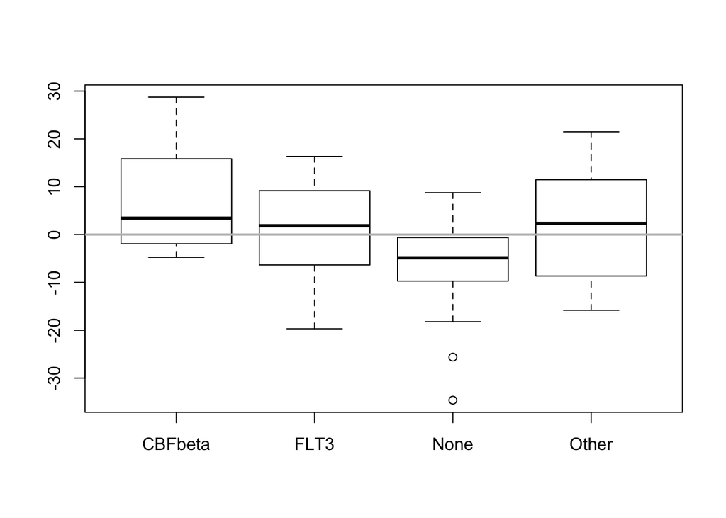

```r
boxplot(change.2191~Mutation, data=AML)
abline(h=0, col='grey', lwd=2)
```

## One-way ANOVA

```r
# with intercept
summary(aov(CD14.2191~Mutation))
```

```
##             Df Sum Sq Mean Sq F value  Pr(>F)
## Mutation     3   9404  3134.7   6.136 0.00101 **
## Residuals   62  31673   510.8
## ---
## Signif. codes:  0 '***' 0.001 '**' 0.01 '*' 0.05 '.' 0.1 ' ' 1
```

```r
(model.1.mut <- anova(lm(CD14.2191~Mutation)))
```

```
## Analysis of Variance Table
##
## Response: CD14.2191
##           Df Sum Sq Mean Sq F value  Pr(>F)
## Mutation   3   9404 3134.73  6.1363 0.00101 **
## Residuals 62  31673  510.85
## ---
## Signif. codes:  0 '***' 0.001 '**' 0.01 '*' 0.05 '.' 0.1 ' ' 1
```

```r
model.1.mut[1,5]
```

```
## [1] 0.001009686
```

```r
# without

summary(aov(change.2191~Mutation-1, data=AML))
```

```
##           Df Sum Sq Mean Sq F value Pr(>F)
## Mutation   4   1787   446.8   3.422 0.0136 *
## Residuals 62   8094   130.6
## ---
## Signif. codes:  0 '***' 0.001 '**' 0.01 '*' 0.05 '.' 0.1 ' ' 1
```

```r
(tmp <- summary(lm(change.2191~Mutation-1, data=AML)))
```

```
##
## Call:
## lm(formula = change.2191 ~ Mutation - 1, data = AML)
##
## Residuals:
##      Min       1Q   Median       3Q      Max
## -27.9394  -9.2113   0.3987   7.6766  20.9260
##
## Coefficients:
##                 Estimate Std. Error t value Pr(>|t|)
## MutationCBFbeta   7.8140     2.9501   2.649   0.0102 *
## MutationFLT3      0.8271     3.0537   0.271   0.7874
## MutationNone     -6.6806     2.6931  -2.481   0.0158 *
## MutationOther     1.7532     2.6213   0.669   0.5061
## ---
## Signif. codes:  0 '***' 0.001 '**' 0.01 '*' 0.05 '.' 0.1 ' ' 1
##
## Residual standard error: 11.43 on 62 degrees of freedom
## Multiple R-squared:  0.1809, Adjusted R-squared:  0.128
## F-statistic: 3.422 on 4 and 62 DF,  p-value: 0.01361
```

## Model matrix

```r
head(model.matrix(CD14.2191~Mutation, data=AML))
```

```
##   (Intercept) MutationFLT3 MutationNone MutationOther
## 1           1            0            0             0
## 2           1            0            0             0
## 3           1            0            0             0
## 4           1            0            0             0
## 5           1            0            0             0
## 6           1            0            0             0
```

```r
head(model.matrix(change.2191~Mutation, data=AML))
```

```
##   (Intercept) MutationFLT3 MutationNone MutationOther
## 1           1            0            0             0
## 2           1            0            0             0
## 3           1            0            0             0
## 4           1            0            0             0
## 5           1            0            0             0
## 6           1            0            0             0
```

```r
head(model.matrix(change.2191~Mutation-1, data=AML))
```

```
##   MutationCBFbeta MutationFLT3 MutationNone MutationOther
## 1               1            0            0             0
## 2               1            0            0             0
## 3               1            0            0             0
## 4               1            0            0             0
## 5               1            0            0             0
## 6               1            0            0             0
```

```r
model.matrix(change.2191~Mutation-1, data=AML)
```

```
##    MutationCBFbeta MutationFLT3 MutationNone MutationOther
## 1                1            0            0             0
## 2                1            0            0             0
## 3                1            0            0             0
## 4                1            0            0             0
## 5                1            0            0             0
## 6                1            0            0             0
## 7                1            0            0             0
## 8                1            0            0             0
## 9                1            0            0             0
## 10               1            0            0             0
## 11               1            0            0             0
## 12               1            0            0             0
## 13               1            0            0             0
## 14               1            0            0             0
```

[output cut: 57 more lines]

```r
model.matrix(change.2191~Mutation+0, data=AML)
```

```
##    MutationCBFbeta MutationFLT3 MutationNone MutationOther
## 1                1            0            0             0
## 2                1            0            0             0
## 3                1            0            0             0
## 4                1            0            0             0
## 5                1            0            0             0
## 6                1            0            0             0
## 7                1            0            0             0
## 8                1            0            0             0
## 9                1            0            0             0
## 10               1            0            0             0
## 11               1            0            0             0
## 12               1            0            0             0
## 13               1            0            0             0
## 14               1            0            0             0
```

[output cut: 57 more lines]

## Model assumptions

```r
library(car)
leveneTest(AML$CD14.2191, AML$Mutation)
```

```
## Levene's Test for Homogeneity of Variance (center = median)
##       Df F value Pr(>F)
## group  3  0.4955 0.6867
##       62
```

```r
shapiro.test(lm(CD14.2191~Mutation, data=AML)$residuals)
```

```
##
##  Shapiro-Wilk normality test
##
## data:  lm(CD14.2191 ~ Mutation, data = AML)$residuals
## W = 0.98035, p-value = 0.3787
```

## Post-hoc tests

```r
pairwise.t.test(CD14.2191, Mutation, data=AML)
```

```
##
##  Pairwise comparisons using t tests with pooled SD
##
## data:  CD14.2191 and Mutation
##
##       CBFbeta FLT3   None
## FLT3  0.1201  -      -
## None  0.0060  0.5145 -
## Other 0.9598  0.1087 0.0031
##
## P value adjustment method: holm
```

# Use Case 2: Dose response studies

## Descriptive statistics

```r
summary(vaccination)
```

```
##     response         dose
##  Min.   : 39.50   0 ml :20
##  1st Qu.: 77.30   10 ml:20
##  Median : 99.25   20 ml:20
##  Mean   : 97.89   30 ml:20
##  3rd Qu.:117.70   40 ml:20
##  Max.   :154.70
```

```r
attach(vaccination)
by(response, dose, mean)
```

```
## dose: 0 ml
## [1] 108.57
## --------------------------------------------------------
## dose: 10 ml
## [1] 119.265
## --------------------------------------------------------
## dose: 20 ml
## [1] 84.025
## --------------------------------------------------------
## dose: 30 ml
## [1] 92.37
## --------------------------------------------------------
## dose: 40 ml
## [1] 85.22
```

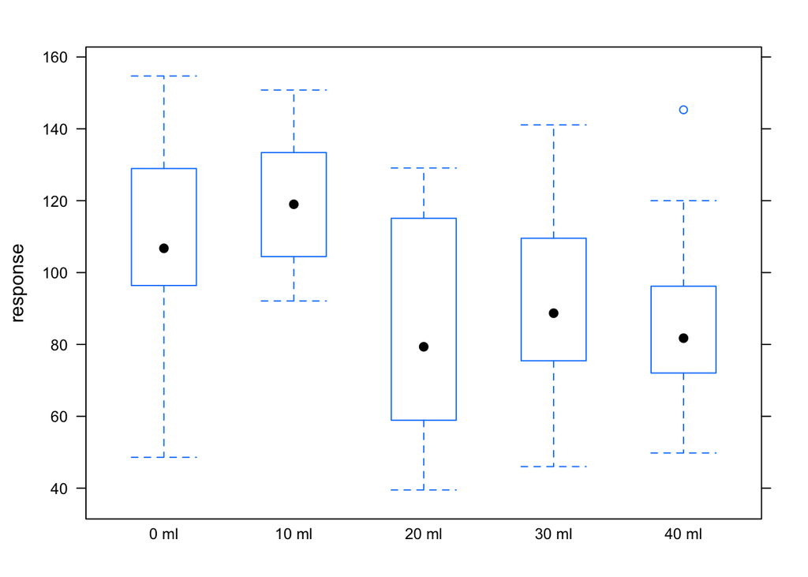

```r
library(lattice)
bwplot(response~dose, data=vaccination)
```

## One-way ANOVA

```r
summary(aov(response~dose, data=vaccination))
```

```
##             Df Sum Sq Mean Sq F value   Pr(>F)
## dose         4  19084    4771   7.929 1.47e-05 ***
## Residuals   95  57164     602
## ---
## Signif. codes:  0 '***' 0.001 '**' 0.01 '*' 0.05 '.' 0.1 ' ' 1
```

## Post-hoc tests

```r
model.va.3 = aov(response~dose, data=vaccination)
TukeyHSD(model.va.3)
```

```
##   Tukey multiple comparisons of means
##     95% family-wise confidence level
##
## Fit: aov(formula = response ~ dose, data = vaccination)
##
## $dose
##                diff       lwr        upr     p adj
## 10 ml-0 ml   10.695 -10.87643  32.266431 0.6426874
## 20 ml-0 ml  -24.545 -46.11643  -2.973569 0.0174170
## 30 ml-0 ml  -16.200 -37.77143   5.371431 0.2336465
## 40 ml-0 ml  -23.350 -44.92143  -1.778569 0.0270291
## 20 ml-10 ml -35.240 -56.81143 -13.668569 0.0001562
## 30 ml-10 ml -26.895 -48.46643  -5.323569 0.0069317
## 40 ml-10 ml -34.045 -55.61643 -12.473569 0.0002808
## 30 ml-20 ml   8.345 -13.22643  29.916431 0.8185005
## 40 ml-20 ml   1.195 -20.37643  22.766431 0.9998712
## 40 ml-30 ml  -7.150 -28.72143  14.421431 0.8878461
```

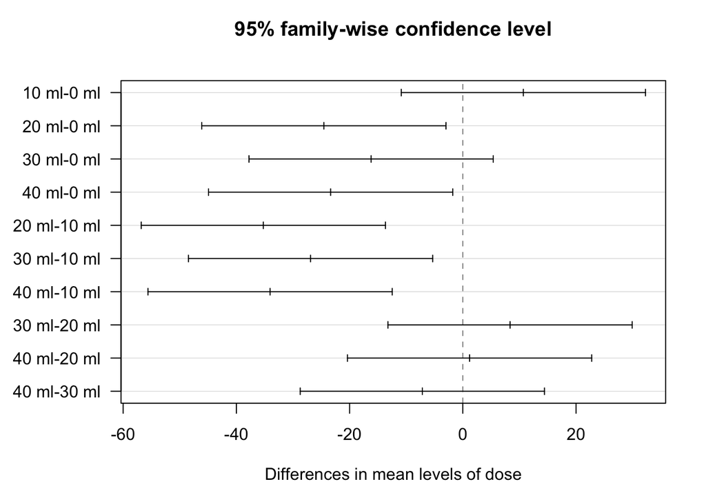

```r
par(mar=c(5,6,4,2))
plot(TukeyHSD(model.va.3), las=1)
```

## Tukey differences

```r
library(agricolae)
model = aov(change.2191~Mutation, data=AML)
HSD.test(model, "Mutation", console = TRUE)
```

```
##
## Study: model ~ "Mutation"
##
## HSD Test for change.2191
##
## Mean Square Error:  130.5507
##
## Mutation,  means
##
##         change.2191      std  r    Min   Max
## CBFbeta   7.8140000 11.66697 15  -4.75 28.74
## FLT3      0.8271429 11.30523 14 -19.70 16.33
## None     -6.6805556 10.87744 18 -34.62  8.74
## Other     1.7531579 11.82173 19 -15.83 21.49
##
## alpha: 0.05 ; Df Error: 62
## Critical Value of Studentized Range: 3.733669
##
## Harmonic Mean of Cell Sizes  16.24152
## Honestly Significant Difference: 10.58552
##
## Means with the same letter are not significantly different.
##
## Groups, Treatments and means
## a     CBFbeta     7.814
## ab    Other       1.753
## ab    FLT3        0.8271
## b     None        -6.681
```

```r
model = aov(response~dose, vaccination)
HSD.test(model, "dose", console = TRUE)
```

```
##
## Study: model ~ "dose"
##
## HSD Test for response
##
## Mean Square Error:  601.7253
##
## dose,  means
##
##       response      std  r  Min   Max
## 0 ml   108.570 25.91789 20 48.6 154.7
## 10 ml  119.265 17.64743 20 92.1 150.8
## 20 ml   84.025 30.42350 20 39.5 129.1
## 30 ml   92.370 24.27206 20 46.0 141.1
## 40 ml   85.220 22.59946 20 49.8 145.3
##
## alpha: 0.05 ; Df Error: 95
## Critical Value of Studentized Range: 3.932736
##
## Honestly Significant Difference: 21.57143
##
## Means with the same letter are not significantly different.
##
## Groups, Treatments and means
## a     10 ml   119.3
## ab    0 ml    108.6
## bc    30 ml   92.37
## c     40 ml   85.22
## c     20 ml   84.02
```

## Student-Newman-Keuls differences

```r
SNK.test(model, "dose", console = TRUE)
```

```
##
## Study: model ~ "dose"
##
## Student Newman Keuls Test
## for response
##
## Mean Square Error:  601.7253
##
## dose,  means
##
##       response      std  r  Min   Max
## 0 ml   108.570 25.91789 20 48.6 154.7
## 10 ml  119.265 17.64743 20 92.1 150.8
## 20 ml   84.025 30.42350 20 39.5 129.1
## 30 ml   92.370 24.27206 20 46.0 141.1
## 40 ml   85.220 22.59946 20 49.8 145.3
##
## alpha: 0.05 ; Df Error: 95
##
## Critical Range
##        2        3        4        5
## 15.39978 18.46964 20.28552 21.57143
##
## Means with the same letter are not significantly different.
##
## Groups, Treatments and means
## a     10 ml   119.3
## a     0 ml    108.6
## b     30 ml   92.37
## b     40 ml   85.22
## b     20 ml   84.02
```

## Least significant differences

```r
LSD.test(model, "dose", p.adj="bonferroni", console = TRUE)
```

```
##
## Study: model ~ "dose"
##
## LSD t Test for response
## P value adjustment method: bonferroni
##
## Mean Square Error:  601.7253
##
## dose,  means and individual ( 95 %) CI
##
##       response      std  r       LCL       UCL  Min   Max
## 0 ml   108.570 25.91789 20  97.68071 119.45929 48.6 154.7
## 10 ml  119.265 17.64743 20 108.37571 130.15429 92.1 150.8
## 20 ml   84.025 30.42350 20  73.13571  94.91429 39.5 129.1
## 30 ml   92.370 24.27206 20  81.48071 103.25929 46.0 141.1
## 40 ml   85.220 22.59946 20  74.33071  96.10929 49.8 145.3
##
## alpha: 0.05 ; Df Error: 95
## Critical Value of t: 2.874073
##
## Least Significant Difference 22.29446
## Means with the same letter are not significantly different.
##
## Groups, Treatments and means
## a     10 ml   119.3
## ab    0 ml    108.6
## bc    30 ml   92.37
## c     40 ml   85.22
## c     20 ml   84.02
```

## Scheffe test

```r
scheffe.test(model, "dose", console = TRUE)
```

```
##
## Study: model ~ "dose"
##
## Scheffe Test for response
##
## Mean Square Error  : 601.7253
##
## dose,  means
##
##       response      std  r  Min   Max
## 0 ml   108.570 25.91789 20 48.6 154.7
## 10 ml  119.265 17.64743 20 92.1 150.8
## 20 ml   84.025 30.42350 20 39.5 129.1
## 30 ml   92.370 24.27206 20 46.0 141.1
## 40 ml   85.220 22.59946 20 49.8 145.3
##
## alpha: 0.05 ; Df Error: 95
## Critical Value of F: 2.467494
##
## Minimum Significant Difference: 24.37009
##
## Means with the same letter are not significantly different.
##
## Groups, Treatments and means
## a     10 ml   119.3
## ab    0 ml    108.6
## bc    30 ml   92.37
## bc    40 ml   85.22
## c     20 ml   84.02
```

## Model assumptions

Homogeneity of Variances

```r
attach(vaccination)
bartlett.test(response~ dose, data=vaccination)
```

```
##
##  Bartlett test of homogeneity of variances
##
## data:  response by dose
## Bartlett's K-squared = 5.6387, df = 4, p-value = 0.2278
```

```r
fligner.test(response~ dose, data=vaccination)
```

```
##
##  Fligner-Killeen test of homogeneity of variances
##
## data:  response by dose
## Fligner-Killeen:med chi-squared = 4.8066, df = 4, p-value = 0.3077
```

```r
leveneTest(response, dose)
```

```
## Levene's Test for Homogeneity of Variance (center = median)
##       Df F value Pr(>F)
## group  4  1.3679 0.2509
##       95
```

```r
leveneTest(response, dose, center=mean)
```

```
## Levene's Test for Homogeneity of Variance (center = mean)
##       Df F value Pr(>F)
## group  4  1.6203 0.1755
##       95
```

# Contrasts

## List of contrasts

```r
t(contr.treatment(5))
```

```
##   1 2 3 4 5
## 2 0 1 0 0 0
## 3 0 0 1 0 0
## 4 0 0 0 1 0
## 5 0 0 0 0 1
```

```r
t(contr.helmert(5))
```

```
##       1  2  3  4 5
## [1,] -1  1  0  0 0
## [2,] -1 -1  2  0 0
## [3,] -1 -1 -1  3 0
## [4,] -1 -1 -1 -1 4
```

```r
t(contr.poly(5))
```

```
##          [,1]       [,2]          [,3]       [,4]      [,5]
## .L -0.6324555 -0.3162278  0.000000e+00  0.3162278 0.6324555
## .Q  0.5345225 -0.2672612 -5.345225e-01 -0.2672612 0.5345225
## .C -0.3162278  0.6324555 -4.095972e-16 -0.6324555 0.3162278
## ^4  0.1195229 -0.4780914  7.171372e-01 -0.4780914 0.1195229
```

```r
t(contr.sdif(5))
```

```
##        1    2    3    4   5
## 2-1 -0.8  0.2  0.2  0.2 0.2
## 3-2 -0.6 -0.6  0.4  0.4 0.4
## 4-3 -0.4 -0.4 -0.4  0.6 0.6
## 5-4 -0.2 -0.2 -0.2 -0.2 0.8
```

```r
model.matrix(response~dose, vaccination)[1:5,]
```

```
##   (Intercept) dose10 ml dose20 ml dose30 ml dose40 ml
## 1           1         0         0         0         0
## 2           1         0         0         0         0
## 3           1         0         0         0         0
## 4           1         0         0         0         0
## 5           1         0         0         0         0
```

```r
model.matrix(response~dose, vaccination,
 contrasts=list(dose=contr.helmert))[1:5,]
```

```
##   (Intercept) dose1 dose2 dose3 dose4
## 1           1    -1    -1    -1    -1
## 2           1    -1    -1    -1    -1
## 3           1    -1    -1    -1    -1
## 4           1    -1    -1    -1    -1
## 5           1    -1    -1    -1    -1
```

```r
model.matrix(response~dose, vaccination,
 contrasts=list(dose=contr.poly))[1:5,]
```

```
##   (Intercept)     dose.L    dose.Q     dose.C    dose^4
## 1           1 -0.6324555 0.5345225 -0.3162278 0.1195229
## 2           1 -0.6324555 0.5345225 -0.3162278 0.1195229
## 3           1 -0.6324555 0.5345225 -0.3162278 0.1195229
## 4           1 -0.6324555 0.5345225 -0.3162278 0.1195229
## 5           1 -0.6324555 0.5345225 -0.3162278 0.1195229
```

## Contrasts in action

```r
summary(lm(response~dose, data = vaccination))
```

```
##
## Call:
## lm(formula = response ~ dose, data = vaccination)
##
## Residuals:
##    Min     1Q Median     3Q    Max
## -59.97 -14.53  -2.77  18.49  60.08
##
## Coefficients:
##             Estimate Std. Error t value Pr(>|t|)
## (Intercept)  108.570      5.485  19.794  < 2e-16 ***
## dose10 ml     10.695      7.757   1.379  0.17121
## dose20 ml    -24.545      7.757  -3.164  0.00209 **
## dose30 ml    -16.200      7.757  -2.088  0.03944 *
## dose40 ml    -23.350      7.757  -3.010  0.00334 **
## ---
## Signif. codes:  0 '***' 0.001 '**' 0.01 '*' 0.05 '.' 0.1 ' ' 1
##
## Residual standard error: 24.53 on 95 degrees of freedom
## Multiple R-squared:  0.2503, Adjusted R-squared:  0.2187
## F-statistic: 7.929 on 4 and 95 DF,  p-value: 1.471e-05
```

```r
kontr = contr.sdif(5)
summary(lm(response ~ dose, data = vaccination, contrasts=list(dose=kontr)))
```

```
##
## Call:
## lm(formula = response ~ dose, data = vaccination, contrasts = list(dose = kontr))
##
## Residuals:
##    Min     1Q Median     3Q    Max
## -59.97 -14.53  -2.77  18.49  60.08
##
## Coefficients:
##             Estimate Std. Error t value Pr(>|t|)
## (Intercept)   97.890      2.453  39.906  < 2e-16 ***
## dose2-1       10.695      7.757   1.379    0.171
## dose3-2      -35.240      7.757  -4.543 1.63e-05 ***
## dose4-3        8.345      7.757   1.076    0.285
## dose5-4       -7.150      7.757  -0.922    0.359
## ---
## Signif. codes:  0 '***' 0.001 '**' 0.01 '*' 0.05 '.' 0.1 ' ' 1
##
## Residual standard error: 24.53 on 95 degrees of freedom
## Multiple R-squared:  0.2503, Adjusted R-squared:  0.2187
## F-statistic: 7.929 on 4 and 95 DF,  p-value: 1.471e-05
```

```r
model.va.7 <- lm(response~ordered(dose), data=vaccination)
summary(model.va.7)
```

```
##
## Call:
## lm(formula = response ~ ordered(dose), data = vaccination)
##
## Residuals:
##    Min     1Q Median     3Q    Max
## -59.97 -14.53  -2.77  18.49  60.08
##
## Coefficients:
##                 Estimate Std. Error t value Pr(>|t|)
## (Intercept)       97.890      2.453  39.906  < 2e-16 ***
## ordered(dose).L  -23.273      5.485  -4.243 5.13e-05 ***
## ordered(dose).Q    2.110      5.485   0.385  0.70133
## ordered(dose).C    9.626      5.485   1.755  0.08249 .
## ordered(dose)^4  -17.761      5.485  -3.238  0.00166 **
## ---
## Signif. codes:  0 '***' 0.001 '**' 0.01 '*' 0.05 '.' 0.1 ' ' 1
##
## Residual standard error: 24.53 on 95 degrees of freedom
## Multiple R-squared:  0.2503, Adjusted R-squared:  0.2187
## F-statistic: 7.929 on 4 and 95 DF,  p-value: 1.471e-05
```

## Compare all contrasts

```r
options()$contrasts
```

```
##         unordered           ordered
## "contr.treatment"      "contr.poly"
```

```r
contrs <- apropos("contr\\.")
coefs <- sapply(contrs, function(i)
 lm(response~dose, data = vaccination,
 contrasts=list(dose=get(i)))$coefficients
)
t(coefs)
```

```
##                 (Intercept)     dose1      dose2      dose3    dose4
## contr.helmert         97.89   5.34750  -9.964167  -2.895833  -3.1675
## contr.Helmert         97.89   5.34750  -9.964167  -2.895833  -3.1675
## contr.poly            97.89 -23.27278   2.110028   9.625973 -17.7611
## contr.SAS             85.22  23.35000  34.045000  -1.195000   7.1500
## contr.sdif            97.89  10.69500 -35.240000   8.345000  -7.1500
## contr.sum             97.89  10.68000  21.375000 -13.865000  -5.5200
## contr.Sum             97.89  10.68000  21.375000 -13.865000  -5.5200
## contr.treatment      108.57  10.69500 -24.545000 -16.200000 -23.3500
## contr.Treatment      108.57  10.69500 -24.545000 -16.200000 -23.3500
```

# Home work 1/2 [deadline 15 X]

Compare range distribution (or studentized range distribution) for SNK/HSD tests between two scenarios: - all groups have equal size (so called balanced case), - some groups have unequal size (so called unbalanced case).

You may use KS-test or QQplots to verify if both distributions are equal.

Try different number of groups and different ways in which classes may be unequal.

Results in form of knitr report shall be submitted on GitHub.

# Home work 2/2 [deadline 29 X]

Finish all tasks in https://rawgithub.com/pbiecek/LinearModels/master/MIMUW_2015/MaterialyPomocnicze/02_lab.html and upload the knitr report (html+Rmd) on GitHub.

For each completed point (2-5) you will receive one point.